# Исследование объявлений о продаже квартир

Выделяем сегмент квартир в центре:

```python
df_spb_center = df_spb.query('city_centers_nearest_km <= 8')
```

Посмотрим на распределение значений в столбце общая площадь:

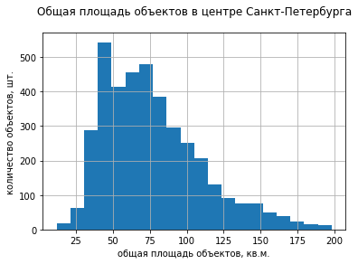

```python
df_spb_center.hist('total_area', bins=20)
plt.xlabel('общая площадь объектов, кв.м.')
plt.ylabel('количество объектов, шт.')
plt.title('Общая площадь объектов в центре Санкт-Петербурга', pad=20);
```

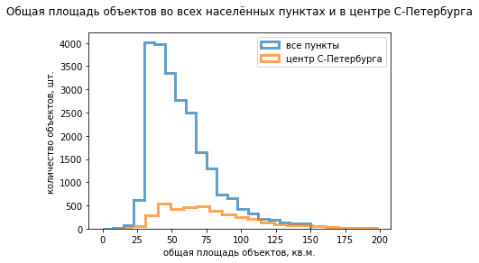

```python
ax = df.plot(kind='hist', y='total_area', histtype='step',bins=20, range=(0,150),
             linewidth=3, alpha=0.7, label='все пункты')
df_spb_center.plot(kind='hist', y='total_area', histtype='step', bins=20, ax=ax,
                   linewidth=3, alpha=0.7, label='центр С-Петербурга')
plt.xlabel('общая площадь объектов, кв.м.')
plt.ylabel('количество объектов, шт.')
plt.title('Общая площадь объектов во всех населённых пунктах и в центре С-Петербурга', pad=20);
```

**Площадь**: большая часть объектов имеет площадь примерно в диапазоне от 40 до 75 м, пик значений приходится на 42-45 кв.м.

По сравнению с выводами по общей таблице, в центре Петербурга больше квартир с большей площадью (42-45 кв.м., тогда как в общей таблице самые многочисленные значения от 25 до 50 кв.м.). Это можно увидеть на общем графике с двумя линиями - оранжевая линия "центр С-Петербурга" не повторяет очертания голубой линии "все пункты", и пики у них находятся немного в разных местах.

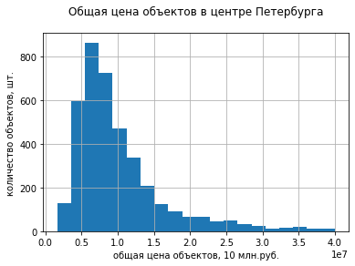

```python
df_spb_center.hist('last_price', bins=20)
plt.xlabel('общая цена объектов, 10 млн.руб.')
plt.ylabel('количество объектов, шт.')
plt.title('Общая цена объектов в центре Петербурга', pad=20);
```

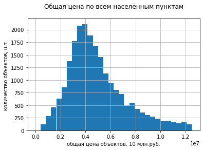

```python
df.hist('last_price', bins=30, range=(0, 12500000))
plt.xlabel('общая цена объектов, 10 млн.руб.')
plt.ylabel('количество объектов, шт.')
plt.title('Общая цена по всем населённым пунктам', pad=20);
```

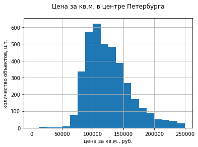

```python
df_spb_center.hist('price_per_square_meter', bins=20, range=(0, 250000))
plt.xlabel('цена за кв.м., руб.')
plt.ylabel('количество объектов, шт.')
plt.title('Цена за кв.м. в центре Петербурга', pad=20);
```

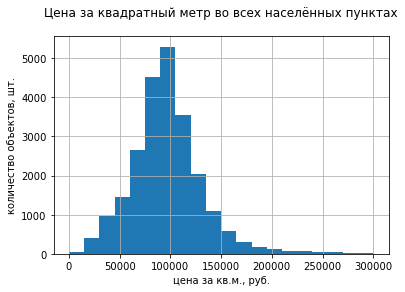

```python
df.hist('price_per_square_meter', bins=20, range=(0,300000))
plt.xlabel('цена за кв.м., руб.')
plt.ylabel('количество объектов, шт.')
plt.title('Цена за квадратный метр во всех населённых пунктах', pad=20);
```

**Общая цена объекта**: в центре Петербурга она выше, чем в других населённых пунктах из общих данных

- в центре Петербурга большинство значений находится в диапазоне 5-8 млн.
- по данным во всех населённых пунктах большинство значений в диапазоне 3-5 млн.

**Цена за квадратный метр**: в центре Петербурга цена выше

- в центре Петербурга пик значений приходится на 80-130 тыс.
- во всех населённых пунктах - 75-120 тыс.

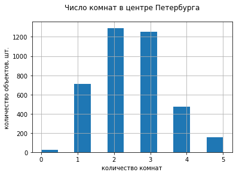

```python
df_spb_center.hist('rooms', bins=11)
plt.xlabel('количество комнат')
plt.ylabel('количество объектов, шт.')
plt.title('Число комнат в центре Петербурга', pad=20);
```

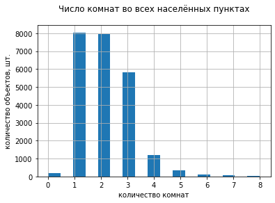

```python
df.hist('rooms', bins=17, range=(0, 8))
plt.xlabel('количество комнат')
plt.ylabel('количество объектов, шт.')
plt.title('Число комнат во всех населённых пунктах', pad=20);
```

**Число комнат**:

- в центре Петербурга большинство квартир 2-х комнатные, и почти столько же 3-х комнатных, 1-комнатных меньше и 4-х комнатных значительно меньше
- во всех населённых пунктах вместе взятых большинство всё-таки 1-комнатных квартир, почти столько же 2-комнатных и меньше 3-комнатных

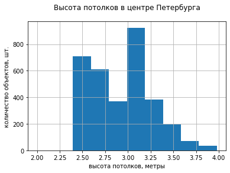

```python
df_spb_center.hist('ceiling_height')
plt.xlabel('высота потолков, метры')
plt.ylabel('количество объектов, шт.')
plt.title('Высота потолков в центре Петербурга', pad=20);
```

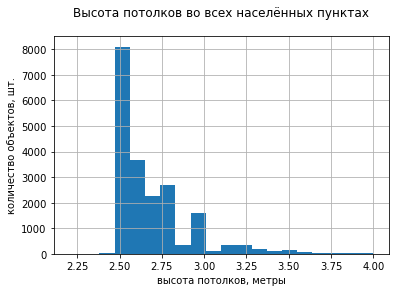

```python
df.hist('ceiling_height', bins=20, range=(2.2, 4))
plt.xlabel('высота потолков, метры')
plt.ylabel('количество объектов, шт.')
plt.title('Высота потолков во всех населённых пунктах', pad=20);
```

**Высота потолков**:

- в центре Петербурга часто встречаются потолки высотой 2.5-2.6м, но наиболее часто встречаются высокие, 3-х метровые потолки
- во всех населённых пунктах картина иная: абсолютное большинство потолков находится в диапазоне 2.4-2.6м, более высокие потолки редкость

Могу предположить, что это связано с историческими зданиями, облик центра Петербурга отличается от одинаковых стандартных 5 и 9 этажных панельных домов, которыми может быть заполнено большинство других населённых пунктов и сам Петербург вдали от центра.

```python
df_spb_center['last_price'].corr(df_spb_center['rooms']) #влияние количества комнат на общую цену в центре города
```

```
0.43006045099660734
```

```python
df_normal['last_price'].corr(df_normal['rooms']) #влияние количества комнат на общую цену в общих данных
```

```
0.4663336768369024
```

```python
df_spb_center['price_per_square_meter'].corr(df_spb_center['rooms'])#влияние количества комнат на цену за кв.м.в центре города
```

```
-0.1726515618331418
```

```python
df_normal['price_per_square_meter'].corr(df_normal['rooms'])#влияние количества комнат на цену за кв.м. в общих данных
```

```
-0.053597665139295196
```

**Число комнат**:

- на общую цену влияет не сильно
- на цену за квадратный метр влияние близко к нулю

Теперь рассмотрим, как влияет на цену категория этажа, на котором размещён объект:

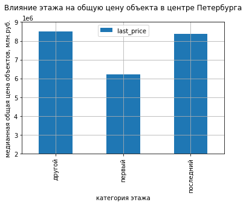

```python
(df_spb_center
     .pivot_table(index='object_floor', values='last_price', aggfunc='median')
     .plot(kind='bar', ylim=(2000000, 9000000), grid=True))
plt.xlabel('категория этажа')
plt.ylabel('медианная общая цена объектов, млн.руб.')
plt.title('Влияние этажа на общую цену объекта в центре Петербурга', pad=20);
```

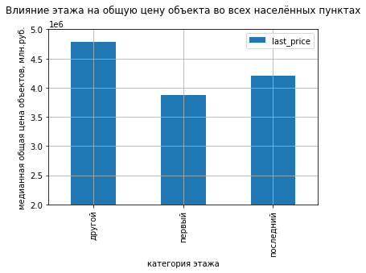

```python
(df_normal
     .pivot_table(index='object_floor', values='last_price', aggfunc='median')
     .plot(kind='bar', ylim=(2000000, 5000000), grid=True))
plt.xlabel('категория этажа')
plt.ylabel('медианная общая цена объектов, млн.руб.')
plt.title('Влияние этажа на общую цену объекта во всех населённых пунктах', pad=20);
```

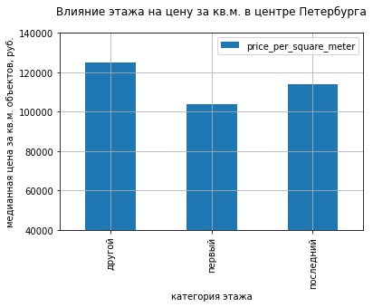

```python
(df_spb_center
     .pivot_table(index='object_floor', values='price_per_square_meter', aggfunc='median')
     .plot(kind='bar', ylim=(40000, 140000), grid=True))
plt.xlabel('категория этажа')
plt.ylabel('медианная цена за кв.м. объектов, руб.')
plt.title('Влияние этажа на цену за кв.м. в центре Петербурга', pad=20);
```

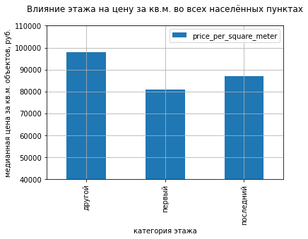

```python
(df_normal
     .pivot_table(index='object_floor', values='price_per_square_meter', aggfunc='median')
     .plot(kind='bar', ylim=(40000, 110000), grid=True))
plt.xlabel('категория этажа')
plt.ylabel('медианная цена за кв.м. объектов, руб.')
plt.title('Влияние этажа на цену за кв.м. во всех населённых пунктах', pad=20);
```

**Этаж**:

- в центре Петербурга **общая цена** объекта на первом этаже ниже, как и во всех населённых пунктах в целом
- но последний этаж в центре Петербурга практически ничем не уступает в цене другим этажам (по сравнению со всеми населёнными пунктами)
- влияние этажа на цену **за квадратный метр** что в центре Петербурга, что в общих данных, примерно похоже

```python
#влияние общей цены на удалённость от центра в центре города
df_spb_center['last_price'].corr(df_spb_center['city_centers_nearest'])
```

```
-0.12884497706998324
```

```python
#влияние общей цены на удалённость от центра в общих данных
df_normal['last_price'].corr(df_normal['city_centers_nearest'])
```

```
-0.3349687799318525
```

```python
#влияние цены за кв.м. на удалённость от центра в центре города
df_spb_center['price_per_square_meter'].corr(df_spb_center['city_centers_nearest'])
```

```
-0.05097634198038638
```

```python
#влияние цены за кв.м. на удалённость от центра в общих данных
df_normal['price_per_square_meter'].corr(df_normal['city_centers_nearest'])
```

```
-0.37713060152099576
```

**Удалённость от центра**:

- в центре Петербурга в целом практически не оказывает влияния ни на общую цену, ни на цену за квадратный метр
- в общих данных есть слабая отрицательная корреляция

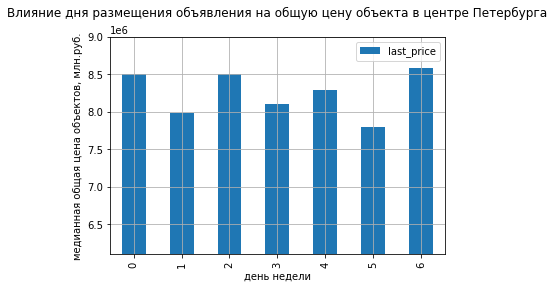

```python
(df_spb_center
    .pivot_table(index='day_of_first_exposition', values='last_price', aggfunc='median')
    .plot(kind='bar', ylim=(6100000, 9000000), grid=True))
plt.xlabel('день недели')
plt.ylabel('медианная общая цена объектов, млн.руб.')
plt.title('Влияние дня размещения объявления на общую цену объекта в центре Петербурга', pad=20);
```

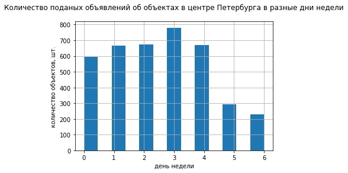

```python
df_spb_center.hist('day_of_first_exposition', bins=13)
plt.xlabel('день недели')
plt.ylabel('количество объектов, шт.')
plt.title('Количество поданых объявлений об объектах в центре Петербурга в разные дни недели', pad=20);
```

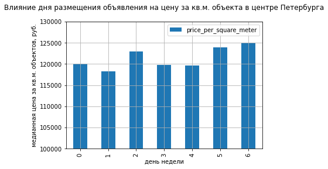

```python
(df_spb_center
    .pivot_table(index='day_of_first_exposition', values='price_per_square_meter', aggfunc='median')
    .plot(kind='bar', ylim=(100000, 130000), grid=True))
plt.xlabel('день недели')
plt.ylabel('медианная цена за кв.м. объектов, руб.')
plt.title('Влияние дня размещения объявления на цену за кв.м. объекта в центре Петербурга', pad=20);
```

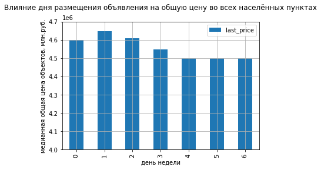

```python
(df_normal
    .pivot_table(index='day_of_first_exposition', values='last_price', aggfunc='median')
    .plot(kind='bar', ylim=(4000000, 4700000), grid=True))
plt.xlabel('день недели')
plt.ylabel('медианная общая цена объектов, млн.руб.')
plt.title('Влияние дня размещения объявления на общую цену во всех населённых пунктах', pad=20);
```

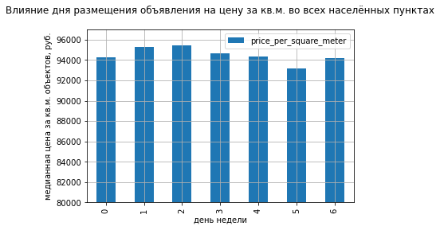

```python
(df_normal
    .pivot_table(index='day_of_first_exposition', values='price_per_square_meter', aggfunc='median')
    .plot(kind='bar', ylim=(80000, 97000), grid=True))
plt.xlabel('день недели')
plt.ylabel('медианная цена за кв.м. объектов, руб.')
plt.title('Влияние дня размещения объявления на цену за кв.м. во всех населённых пунктах', pad=20);
```

**День подачи объявления**:

- **в центре Петербурга** объявления, размещённые в воскресенье, понедельник и среду чаще имеют более высокую **общую стоимость** объекта (хотя таких объявлений подаётся меньше, как видно на гистограмме)
- пятница и четверг относительно удачные дни для размещения объявления в надежде продать объект по более высокой цене
- а вторник и суббота показывают худшие результаты (хотя во вторник объявлений выходит много)
- **во всех населённых пунктах** ситуация иная:
- объявления о квартирах, которые продаются в итоге по лучшей цене, размещаются во вторник, среду, понедельник
- четверг - показывает менее удачный результат
- и самая низкая цена оказывается у объектов, объявления о продаже которых размещали в пятницу, субботу, воскресенье

Что касается влияния дня недели на **цену за квадратный метр**:

- **в центре Петербурга** более высокий результат дают объявления, размещённые в воскресенье и субботу, а также в среду
- более скромный результат у понедельника, четверга, пятницы
- и самые низкие результаты у вторника
- **во всех населённых пунктах**:
- среда и вторник более удачные дни
- средние результаты у четверга, понедельника, пятницы и воскресенья
- и самый низкий результат в субботу

Важно отметить, что колебания цены за кв.м. в общей таблице происходит в диапазоне 2.5тыс. руб.(от 93 до 95.5 тыс.), в то время как колебания цены за кв.м. в центре Петербурга более существенно, оно находится в диапазоне 7 тыс.руб. (от 118 до 125 тыс.).

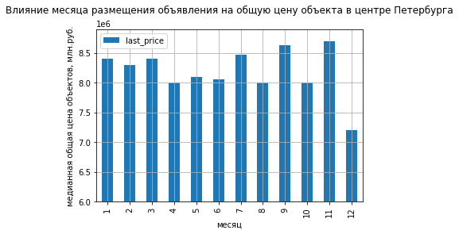

```python
(df_spb_center
    .pivot_table(index='month_of_first_exposition', values='last_price', aggfunc='median')
    .plot(kind='bar', ylim=(6000000, 8900000), grid=True))
plt.xlabel('месяц')
plt.ylabel('медианная общая цена объектов, млн.руб.')
plt.title('Влияние месяца размещения объявления на общую цену объекта в центре Петербурга', pad=20);
```

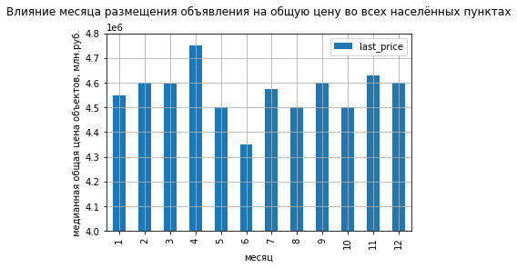

```python
(df_normal
    .pivot_table(index='month_of_first_exposition', values='last_price', aggfunc='median')
    .plot(kind='bar', ylim=(4000000, 4800000), grid=True))
plt.xlabel('месяц')
plt.ylabel('медианная общая цена объектов, млн.руб.')
plt.title('Влияние месяца размещения объявления на общую цену во всех населённых пунктах', pad=20);
```

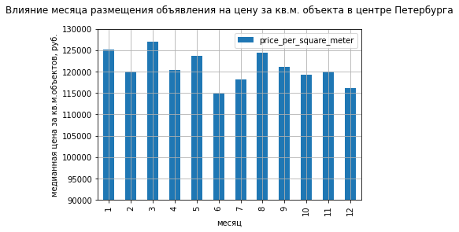

```python
(df_spb_center
    .pivot_table(index='month_of_first_exposition', values='price_per_square_meter', aggfunc='median')
    .plot(kind='bar', ylim=(90000,130000), grid=True))
plt.xlabel('месяц')
plt.ylabel('медианная цена за кв.м.объектов, руб.')
plt.title('Влияние месяца размещения объявления на цену за кв.м. объекта в центре Петербурга', pad=20);
```

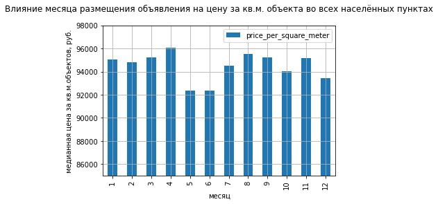

```python
(df_normal
    .pivot_table(index='month_of_first_exposition', values='price_per_square_meter', aggfunc='median')
    .plot(kind='bar', ylim=(85000, 98000), grid=True))
plt.xlabel('месяц')
plt.ylabel('медианная цена за кв.м.объектов, руб.')
plt.title('Влияние месяца размещения объявления на цену за кв.м. объекта во всех населённых пунктах', pad=20);
```

**Месяц подачи объявления**:

- объявления, размещённые в ноябре, сентябре и июле имеют более высокую **общую цену** для объектов **в центре Петербурга**
- средний результат у объявлений, размещённых в январе, феврале, марте
- май, июнь, апрель, август, октябрь несколько отстают от других месяцев
- и худший результат у декабря
- **во всех населённых пунктах** апрель показывает лучший результат
- ноябрь, февраль, сентябрь, декабрь, март имеют результат выше среднего
- далее располагаются июль, январь
- май, август, октябрь показывают результат похуже
- и самый слабый результат у июня

Данные о **цене за квадратный метр** дают другие результаты:

- **в центре Петербурга** более высокую цену за кв.м. имеют объекты, объявления о которых разместили в марте, январе, августе, мае
- сентябрь, апрель, февраль, ноябрь, октябрь имеют средние результаты
- и внизу условного рейтинга находятся июль, декабрь, июнь
- **во всех населённых пунктах** лучшие результаты у апреля, августа
- средние показатели у марта, сентября, ноября, января, февраля, июля, октября
- и три худшие месяца это декабрь, май, июнь

**Таким образом**, выводы по данным отличаются, смотря через какой показатель смотреть. Можно выделить часто совпадающие элементы:

- **худшим временем** являются месяцы **май, июнь, декабрь**. Вероятно, это связано с каникулами/отпусками, число потенциальных покупателей снижается в такие периоды и это в итоге влияет на цену.
- **ноябрь** удачный месяц и по общим данным, и для центра Петербурга
- **апрель** удачный месяц по общим данным, но для центра Петербурга - средний результат

Такое разнообразие "рейтингов", за исключением явных совпадающих тенденций (описанных выше), говорит о том, что больше устойчивого влияния месяца размещения объявления на цену не выявлено.

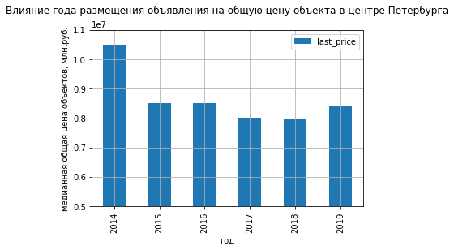

```python
(df_spb_center
    .pivot_table(index='year_of_first_exposition', values='last_price', aggfunc='median')
    .plot(kind='bar', ylim=(5000000, 11000000), grid=True))
plt.xlabel('год')
plt.ylabel('медианная общая цена объектов, млн.руб.')
plt.title('Влияние года размещения объявления на общую цену объекта в центре Петербурга', pad=20);
```

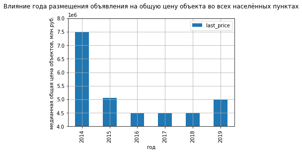

```python
(df_normal
    .pivot_table(index='year_of_first_exposition', values='last_price', aggfunc='median')
    .plot(kind='bar', ylim=(4000000, 8000000), grid=True))
plt.xlabel('год')
plt.ylabel('медианная общая цена объектов, млн.руб.')
plt.title('Влияние года размещения объявления на общую цену объекта во всех населённых пунктах', pad=20);
```

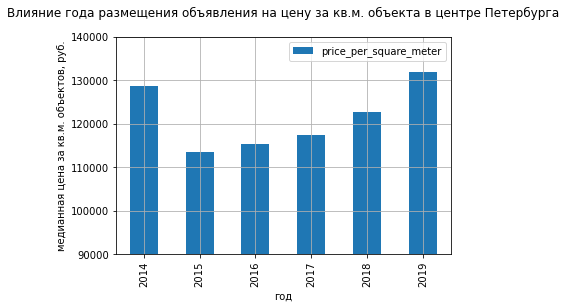

```python
(df_spb_center
    .pivot_table(index='year_of_first_exposition', values='price_per_square_meter', aggfunc='median')
    .plot(kind='bar', ylim=(90000, 140000), grid=True))
plt.xlabel('год')
plt.ylabel('медианная цена за кв.м. объектов, руб.')
plt.title('Влияние года размещения объявления на цену за кв.м. объекта в центре Петербурга', pad=20);
```

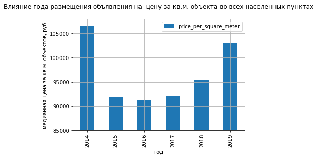

```python
(df_normal
    .pivot_table(index='year_of_first_exposition', values='price_per_square_meter', aggfunc='median')
    .plot(kind='bar', ylim=(85000, 108000), grid=True))
plt.xlabel('год')
plt.ylabel('медианная цена за кв.м. объектов, руб.')
plt.title('Влияние года размещения объявления на  цену за кв.м. объекта во всех населённых пунктах', pad=20);
```

**Год размещения объявления**:

- **в центре Петербурга** самая высокая **общая цена** была у объектов в 2014 году
- средняя цена была в 2015, 2016 и 2019 годах
- и самая низкая в 2017 и 2018 годах
- **во всех населённых пунктах** самая высокая цена у объектов в 2014 году
- средняя в 2015 и 2019 годах
- и самая низкая в 2016, 2017 и 2018 годах

**Таким образом**, данные в целом показывают похожие тенденции, но:

- для центра Петербурга перепад более сглаженный (диапазон от 8 до 10.5 млн, т.е. колебания в размере 2.5млн, в то время как в общих данных перепад от 4.5 до 7.5 млн, т.е. колебания цены в размере 3 млн)
- для центра Петербурга 2016 год был более удачным, чем для всех населённых пунктов (2016 удержался на уровне 2015 года, в то время как в общих данных было падение)

Что касается **цены за квадратный метр**,

- в **центре Петербурга** после ощутимого падения после 2014 года она показывает устойчивый рост (с более медленным подъёмом между 2016 и 2017 годами и усиливающимся к 2018 и 2019 годам)
- и **во всех населённых пунктах** такое же ощутимое падение после 2014 года, но ещё практически незаметное, но тоже падение к 2016 году, и затем только рост, тоже переходящий из среднего в 2017-2018 годах к большому росту к 2019 году

Можно отметить, что цена за кв.м. в центре Петербурга растёт больше: от минимального (113) к максимальному значению (132) выросла примерно на 19 тыс.руб., в то время как в общих данных рост составил от минимального (92) до максимального значения (107) около 15 тыс.руб.

Также интересно отметить, что недвижимость в центре Петербурга смогла "отыграть" большое падение после 2014 года, и даже немного превзойти прежний показатель, в отличие от ситуации со всеми населёнными пунктами вместе взятыми. (Но тут опять-таки надо помнить, что данных за 2014 год крайне мало, чтобы делать точные, уверенные выводы).

## Общий вывод и рекомендации

В ходе исследовательского анализа данных были изучены различные параметры, их распределение и влияние на стоимость объекта недвижимости. Исследование было проведено и для общих данных (Санкт-Петербург и прилежащие населённые пункты), и отдельно для центра Петербурга.

**Площадь**: в предоставленных общих данных наиболее часто встречаются объекты с площадью от 30 до 50 кв.м., (самое массовое значение среди них занимают объекты площадью 45 кв.м.). Квартиры с большей площадью (если быть точнее, с площадью более 63 кв.м.) встречаются реже (чем больше площадь - тем реже встречаются, на графике виден постепеннный спад значений). Немного неожиданно, что всё-таки довольно много объектов с необычно большой площадью, например, более 100 кв.м.

В центре Санкт-Петербурга большая часть объектов имеет площадь примерно в диапазоне от 40 до 75 кв.м., т.е. в центре Петербурга объекты чаще имеют большую площадь, чем в общих данных.

*Коэффициент корреляции Пирсона* показывает, что стоимость объекта зависит от общей площади, причём зависимость эта положительная (чем больше площадь, тем выше и цена) и достаточно сильная.

**Цена**: в исследовании рассмотрены **два параметра** для того, чтобы детальнее погрузиться во взаимосвязь стоимости и других параметров и точнее определить их влияние.

**Общая цена объекта**: в центре Петербурга она выше, чем в других населённых пунктах из общих данных

- в центре Петербурга большинство значений находится в диапазоне 5-8 млн.
- по данным во всех населённых пунктах большинство значений в диапазоне 3-5 млн.

**Цена за квадратный метр**: в центре Петербурга цена выше

- в центре Петербурга пик значений приходится на 80-130 тыс.
- во всех населённых пунктах - 75-120 тыс.

**Число комнат**:

- во всех населённых пунктах вместе взятых большинство 1-комнатных квартир, почти столько же 2-комнатных и меньше 3-комнатных
- в центре Петербурга большинство квартир 2-х комнатные, и почти столько же 3-х комнатных, 1-комнатных меньше

*Коэффициент корреляции Пирсона* показывает:

- зависимость цены от числа комнат выражена положительным коэффициентом (больше комнат - больше цена), но эта зависимость выражена слабо (в центре Санкт-петербурга влияние чуть слабее, чем в общих данных)
- влияния количества комнат на цену за кв.м. практически нет и корреляция отрицательная (больше комнат - ниже цена за кв.м.)

**Высота потолков**:

- в общих данных абсолютное большинство потолков находится в диапазоне 2.4-2.6м, более высокие потолки - редкость
- в центре Петербурга наобоорот, наиболее часто встречаются потолки высотой около 3м, а более стандартные потолки высотой 2.4-2.6 метра отступают на второй план Могу предположить, что это связано с историческими зданиями, облик центра Петербурга отличается от одинаковых стандартных панельных домов, которыми может быть заполнено большинство других населённых пунктов и сам Петербург вдали от центра.

**Время продажи квартиры**:

Чаще всего продажа происходит в течение первых 2-3 месяцев, причём есть выбивающиеся наиболее многочисленные значения: 45, 60, 7, 30 и 90 дней. Далее идёт постепенный спад значений, который может тянуться вплоть до 3.5 - 4 лет.

Длинный "хвост" гистограммы влияет на среднее арифметическое: оно показывает, что продажа в среднем занимает 181 день (т.е. примерно 6 мес.), тогда как медиана показывает, что в среднем продажа происходит через 95 дней (около 3 мес.).

Можно считать, что продажа происходит быстро, если она происходит в срок до 45 дней.

И можно считать, что продажа происходит необычно долго, если она занимает более 513 дней.

**Удалённость от центра**:

*Коэффициент корреляции Пирсона показывает*:

- удалённость от центра оказывает слабое влияние и на общую цену, и на цену за кв.м. и оно выражено отрицательным коэффициентом (чем больше удалённость от центра, тем ниже цена)

**Удалённость от центра в километрах**: Графики, показывающие среднюю цену в зависимости от степени удалённости от центра, имеют **общую тенденцию**: чем ближе к центру, тем цена выше (это касается и общей цены, и цены за кв.м.).

Судя по ним, **центральная зона** находится в диапазоне от 0 до 8 км включительно (здесь наиболее высокие значения на обоих графиках).

**Этаж**, на котором расположен объект (первый, последний, другой):

- самая низкая стоимость у квартир на первых этажах
- чуть лучше дела обстоят у квартир, расположенных на последних этажах
- и лучшая стоимость у квартир на любых других этажах Графики показывают, что этот эффект наблюдается и в расчётах с общей ценой объекта, и с ценой за квадратный метр.
- это всё справедливо и для центра Санкт-Петербурга, но есть одна особенность: последний этаж в центре Петербурга практически не уступает в цене другим этажам

**День размещения объявления**:

Расчёт взаимосвязи цены и дня размещения объявления при разных подходах даёт разный результат (расчёт общей цены и цены за кв.м., расчёт в общих данных и в центре Петербурга).

**Общий вывод** состоит в том, что в общих данных более высокую цену имеют объекты, объявления о которых разместили в будние дни, а в центре Петербурга - наоборот, в выходные дни.

Возможно, остальная, более точная **корреляция по дням недели носит случайный характер. Устойчивой однозначной взаимосвязи в данных не обнаружено** ("рейтинги" более удачных в отношении цены дней при разных подходах каждый раз оказываются разными).

**Месяц подачи объявления**:

При расчётах с ценой за кв.м., **март и апрель** показывают удачные результаты для центра Петербурга и для всех населённых пунктов соответственно, а **июнь** одинаково неудычный месяц. Остальные соотношения **отличаются**.

**Общий вывод**: такое разнообразие "рейтингов" месяцев опять говорит о том, что одной ключевой, единственно верной взаимосвязи в данных не наблюдается, но есть небольшой эффект сезонности:

- **худшим временем** являются месяцы **май, июнь, декабрь**. Вероятно, это связано с каникулами/отпусками, число потенциальных покупателей снижается в такие периоды и это в итоге влияет на цену.

**Год размещения объявления**:

При расчётах с **общей ценой** данные в центре Петербурга и во всех населённых пунктах в целом показывают похожие тенденции:

- сильное падение после 2014 года
- нижние показатели в 2017, 2018 годах
- уверенный подъём к 2019 году
- для центра Петербурга перепад более сглаженный (диапазон от 8 до 10.5 млн, т.е. колебания в размере 2.5млн, в то время как в общих данных перепад от 4.5 до 7.5 млн, т.е. колебания цены в размере 3 млн)
- для центра Петербурга 2016 год был более удачным, чем для всех населённых пунктов (2016 удержался на уровне 2015 года, в то время как в общих данных было падение)

Что касается **цены за квадратный метр**,

- в **центре Петербурга** после ощутимого падения после 2014 года она показывает устойчивый рост (с более медленным подъёмом между 2016 и 2017 годами и усиливающимся к 2018 и 2019 годам)
- и **во всех населённых пунктах** такое же ощутимое падение после 2014 года, но ещё практически незаметное, но тоже падение к 2016 году, и затем только рост, тоже переходящий из среднего в 2017-2018 годах к большому росту к 2019 году

**Таким образом**, данные с некоторой вариативностью показывают **две главные тенденции**:

- сильное падение после 2014 года
- усиливающийся рост от 2017 к 2019 году

При этом надо понимать, что данных за 2014 год крайне мало, и за 2019 год тоже мало по сравнению с другими годами (а малая выборка может искажать в целом достоверность выводов).

Среди **10 населённых пунктов** с наибольшим числом объявлений можно выделить:

- населённые пункты с самой **высокой** средней ценой за квадратный метр (т.е.стоимостью жилья):
  - Санкт-Петербург
  - Пушкин
  - деревня Кудрово
- населённые пункты с самой **низкой** стоимостью жилья:
  - Выборг
  - Всеволожск
  - Гатчина

Важно отметить, что именно **географическое расположение объекта на периферии или в самом Петербурге, или тем более его центре, даёт самую ощутимую разницу в цене за кв.м. объекта**. Так, например, в Выборге (последний населённый пункт из отобранных топ-10) средняя цена за кв.м. составляет 58 тыс.руб., в самом Петербурге 111 тыс.руб., а в центре города от 120 до 140 тыс.руб. за кв.м.

**Рекомендации**: Возможно, представление о факторах, влияющих на стоимость квартир, могли бы дополнить данные о пешей доступности **метро** в черте города и о о доступности и времени в пути на электричке до Санкт-Петербурга для прилежащих населённых пунктов. Ещё одним интересным фактором может быть **год постройки здания** и сведения о проведённом или не проведённом в нём капитальном **ремонте**. Также на цену могут влиять: ремонт в самой квартире, наличие или отсутствие в ней мебели, наличие или отсутствие в доме лифта и консьержа/охраны. Возможно, автоматический сбор таких сведений как пешая доступность до ближайшей поликлиники, школы, детского сада важнее для некоторых (или многих) людей, чем расстояние до ближайшего пруда. Также для потенциальных покупателей может представлять интерес наличие/отсутствие парковочного места и расположение окон (на север, юг, запад, восток). Сбор дополнительных сведений подобного рода мог бы сделать исследование объявлений ещё более детальным и глубоким. А для избегания появления аномалий в датасете хотелось бы продумать некоторые детали системы сбора данных: например, чтобы при заполнении данных появлялись подсказки типовых ответов или предупреждения при указывании нестандартной высоты потолков, чтобы пользователь мог вовремя обратить на это внимание.

Спасибо за внимание!